# Second Launch Prep s’more-002

Published

November 5, 2025

[figure not shown]

Attempt1: Bad balloons, geese and clouds

## Payload weight

- USB connector removed from U4B.
- With antenna winders: 31.7 gram.
- Antenna winder 1: 7.6 gram
- Antenna winder 2: 7.4 gram
- Total antenna winder: 15 gram
- Payload weight: 16.7 gram

## Filling Calculations

### Define basic balloon parameters

```julia
free_lift = 5.0u"g" # grams
balloon_weight = 38.0u"g" # gram
balloon_volume = 0.15u"m^3" # m^3
payload_weight = 16.7u"g" # gram
gas = "helium 97%"

# compare 1 and 2 balloons
balloon_1 = Balloon(balloon_weight, balloon_volume)
balloon_2 = balloon_1 * 2
```

```
Balloon(0.076 kg, 0.3 m³)
```

### Look at options as a function of free lift

```julia
free_lifts = collect(0.0:1.0:10.0)u"g"
bss1 = BalloonSystem(balloon_1, payload_weight, free_lifts, gas)
bss2 = BalloonSystem(balloon_2, payload_weight, free_lifts, gas)
```

[output not shown]

Free lift is the excess lift due to the super-pressure of the balloon.

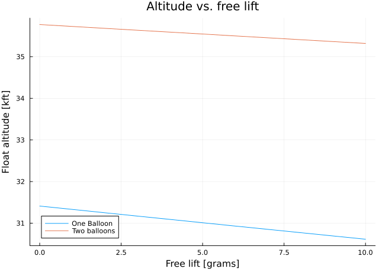

Figure 1: Float altitude vs. free lift

```julia
plot(
    ustrip(u"g",free_lifts),
    ustrip(us"ft",bss1.float_altitude)/1000.,
    label="One Balloon",
    title="Altitude vs. free lift",
    xlabel="Free lift [grams]",
    ylabel="Float altitude [kft]",
)
plot!(ustrip(u"g",free_lifts),
      ustrip(us"ft",bss2.float_altitude)/1000.,
      label="Two balloons",
)
```

Neck lift if the amount of lift that’s used to fill a balloon. For a two balloon system, this is the total, so divide by two to get the amount for each balloon.

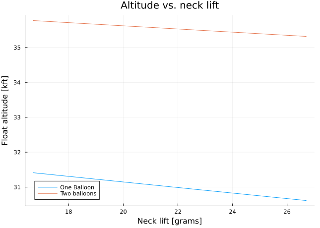

Figure 2: Float altitude vs. neck lift

```julia
plot(
    ustrip(u"g",bss1.neck_lift),
    ustrip(us"ft",bss1.float_altitude)/1000.,
    label="One Balloon",
    title="Altitude vs. neck lift",
    xlabel="Neck lift [grams]",
    ylabel="Float altitude [kft]",
)
plot!(ustrip(u"g",bss2.neck_lift),
      ustrip(us"ft",bss2.float_altitude)/1000.,
      label="Two balloons",
)
```

Generally, more free lift means that there is extra gas and the balloon will stay aloft longer as the gas slowly leaks or diffuses out.

For this launch, there will be two balloons carrying the payload. A free lift of 5 grams means a neck lift of 22 grams total or 11 grams per balloon.

## 2025-10-16

Set up balloon payload on wooden poles with horizontal wiring in morning of 2025-10-16 and let it start with sunrise.

[figure not shown]

### wspr.rocks spots

Downloaded spot from https://wspr.rocks in both json and tsv format for comparison.

These are the spots from one day of testing 2025-10-16 local time 2025-10-16-wpsr-rocks-spots.json 2025-10-16-wpsr-rocks-spots.tsv

### lu7aa spots

https://lu7aa.org.ar/wsprx.asp?banda=All&other=KF8EEZ&balloonid=&timeslot=&SSID=&launch=&tracker=qrplabs

csv file created by copy/paste from website

2025-10-16-lu7aa-spots.csv

this shows decoded telemetry also https://lu7aa.org/wsprx.asp?banda=20m&other=kf8eez&balloonid=05&timeslot=8&repito=on&qrpid=109&SSID=11&launch=20251016010101&tracker=qrplabs

### wsprtv.com

shows charts https://wsprtv.com/?cs=kf8eez&ch=109&band=20m&start_date=2025-09-17

downloaded csv to KF8EEZ_109_20250917-20251017.cs

### power down

Solar panel ends in shadow early due to trees.

Let up over night to allow to start again with sunrise.

## 2025-10-17

Came back up after overnight testing and starting transmitting. Brought inside due to forecast rain overnight.

## 2025-10-20

Additonal testing. Working in sun.

## 2025-10-23

Broke off the USB connector from the U4B and mounted again outside for testing. Partly cloudy but transmitted fine during sun.

## U4B and programming information

qrp-labs S/N: 21894

## Hardware

Part | no | weight |  
Powerfilm MPT48-150 | 1 | 3.8 |  
supercap AVX_SCC_3_0V-2952762 | 2 | 2.4 |  
volt regulator L7805CV | 1 | 1.7 |  
u4b | 1 | 5.4 |  
upper HF antenna + rigging | 1 | 4.1 |  
lower HF antenna | 1 | 0.9 |  
TOTAL | | 18.2 |

## Configuration

- Callsign: KF8EEZ
- Band: 20m
- Channel: 109
- Autostart: TRACKER2

## Programs

### Tracker 2

This is the primary program. The MYTELE and MYGPS subroutines enable control of a test mode which doesn’t need GPS or ability to transmit.

```
PRINT "START TRACKER2"
RUN "INIT"
RUN "SHOW"
PRINT "INITIAL GPS"
RUN "MYGPS"
10 PRINT "LOOP AT #VC"
RUN "SHOW"
RUN "MYTELE"
LET C = C + 1
IF C > N
    LET HP = 1
ENDIF
RUN "MYGPS"
GOTO 10
```

### Init

- C is the count of transmissions since wake up
- N is the number of transmissions before switching to high-power (0-based)
- T is a flag for test mode
  - T=1 - test mode
  - T=0 - live mode

```
PRINT "INIT START"
LET CH = 109
LET HP = 0
LET C = 0
LET N = 2
LET T = 0
PRINT "HOST USB:    #US"
PRINT "HIGH POWER:  #HP"
PRINT "FREQUENCY:   #FQ"
PRINT "CHANNEL:     #CH"
PRINT "CALLSIGN:    #CS"
PRINT "TEMPERATURE: #TK"
IF T = 1
PRINT "FAKE GPS/TELE MODE"
ELSE
PRINT "REAL GPS/TELE MODE"
ENDIF
PRINT "INIT DONE"
```

### Show

Prints out the current state

```
PRINT "SHOW START"
PRINT "LLH:  #LT #LN #AT"
PRINT "GPS:  VALID: #GV LOCK: #GL SPEED: #GS CALIB: #CL"
PRINT "GPS:  NSAT:  #SC"
PRINT "CNT:  #VC"
PRINT "TEMP: #TK"
PRINT "POWR: #HP"
PRINT "SHOW DONE"
```

### MYGPS

This is my GPS program, it lets you use the GPS in a test mode without an actual signal. Don’t acquire GPS if in test mode (T=1)

```
PRINT "GPS START"
RUN "LEDOFF"
IF T = 0
PRINT "REAL GPS"
GPS 360
ELSE
PRINT "FAKE GPS"
DELAY 2000
ENDIF
RUN "LEDON"
PRINT "GPS END"
```

### MYTELE

Don’t transmit if in test mode (T=1)

```
PRINT "TELEMETRY START"
RUN "LEDOFF"
IF T = 0
PRINT "REAL TELE"
TELE
ELSE
PRINT "FAKE TELE"
DELAY 2000
ENDIF
RUN "LEDON"
PRINT "TELEMETRY END"
```

### LED off

```
OUT 19 1
```

### LED on

```
OUT 19 0
```

## Ground testing telemetry

One set of telemetry from ground testing

```
251016 1736  35  0.32  14.0970715  KF8EEZ EM79 10          0  0.80  1  1    0  0   0     1   810
251016 1736 -28  0.37  14.0971916  KF8EEZ EM79 10          0  0.47  1  1   56  1  34     1   810
251016 1738  10  0.24  14.0970673  0X5DBN OI57 53          0  0.12  3  1   -8  1  31     1   810
251016 1738  34  0.32  14.0970714  0X5DBN OI57 53          0  0.76  1  1    0  0   0     1   808
251016 1738 -20  0.49  14.0971915  0X5DBN OI57 53          0  0.19  3  1    0  0  13     1   429
```